# STATS 506

Author

Sky Shi

Modified

October 31, 2024

The link to the problem set 4 GitHub repository is at: https://github.com/skyshi1/STAT506/tree/main/problemSet4, as a sub-folder of the STATS 506 repository.

## Problem 1 - Tidyverse

### a. Tables for departure delay and arrival delay

```r
# Package installed by install.packages("nycflights13")
# Load the necessary packages, suppressing the warning messages about conflicting functions
suppressPackageStartupMessages({
  library(tidyverse)
  library(nycflights13)  # This package includes flights and airports data
})
```

Generate the table for mean and median departure delay per airport:

```r
# Create the summary table of departure delays
departure_delay_summary <- flights %>%
  left_join(airports, by = c("origin" = "faa")) %>%  # Join with the airports dataset to include airport names
  rename(airport_name = name) %>%  # Rename for clarity
  group_by(airport_name) %>%  # Group by airport name to calculate delay statistics
  summarise(
    mean_dep_delay = mean(dep_delay, na.rm = TRUE),  # Calculate mean delay
    median_dep_delay = median(dep_delay, na.rm = TRUE),  # Calculate median delay
    flight_count = n()  # Count the number of flights
  ) %>%
  filter(flight_count >= 10) %>%  # Exclude airports with fewer than 10 flights
  arrange(desc(mean_dep_delay)) %>%  # Order by descending mean departure delay
  rename(  # Format the output as a nicely labeled tibble
    "Airport Name" = airport_name,
    "Mean Departure Delay (min)" = mean_dep_delay,
    "Median Departure Delay (min)" = median_dep_delay,
    "Number of Flights" = flight_count
  )

# Print all rows of departure delay table
print(departure_delay_summary, n = Inf)
```

```
# A tibble: 3 × 4
  `Airport Name`      `Mean Departure Delay (min)` Median Departure Delay (min…¹
  <chr>                                      <dbl>                         <dbl>
1 Newark Liberty Intl                         15.1                            -1
2 John F Kennedy Intl                         12.1                            -1
3 La Guardia                                  10.3                            -3
# ℹ abbreviated name: ¹`Median Departure Delay (min)`
# ℹ 1 more variable: `Number of Flights` <int>
```

Generate the table for mean and median arrival delay per airport:

```r
# Create the summary table of arrival delays
arrival_delay_summary <- flights %>%
  left_join(airports, by = c("dest" = "faa")) %>%  # Join with the airports dataset to include airport names
  rename(airport_name = name) %>%  # Rename for clarity
  group_by(airport_name) %>%  # Group by airport name to calculate delay statistics
  summarise(
    mean_arr_delay = mean(arr_delay, na.rm = TRUE),  # Calculate mean arrival delay
    median_arr_delay = median(arr_delay, na.rm = TRUE),  # Calculate median arrival delay
    flight_count = n()  # Count the number of flights
  ) %>%
  filter(flight_count >= 10) %>%  # Exclude destinations with fewer than 10 flights
  arrange(desc(mean_arr_delay)) %>%  # Order by descending mean arrival delay
  rename(  # Format the output as a nicely labeled tibble
    "Airport Name" = airport_name,
    "Mean Arrival Delay (min)" = mean_arr_delay,
    "Median Arrival Delay (min)" = median_arr_delay,
    "Number of Flights" = flight_count
  )

# Print all rows of the arrival delay table
print(arrival_delay_summary, n = Inf)
```

```
# A tibble: 99 × 4
   `Airport Name`                  Mean Arrival Delay (…¹ Median Arrival Delay…²
   <chr>                                            <dbl>                  <dbl>
 1 "Columbia Metropolitan"                        41.8                      28
 2 "Tulsa Intl"                                   33.7                      14
 3 "Will Rogers World"                            30.6                      16
 4 "Jackson Hole Airport"                         28.1                      15
 5 "Mc Ghee Tyson"                                24.1                       2
 6 "Dane Co Rgnl Truax Fld"                       20.2                       1
 7 "Richmond Intl"                                20.1                       1
 8 "Akron Canton Regional Airport"                19.7                       3
 9 "Des Moines Intl"                              19.0                       0
10 "Gerald R Ford Intl"                           18.2                       1
11 "Birmingham Intl"                              16.9                      -2
12 "Theodore Francis Green State"                 16.2                       1
```

[output cut: 90 more lines]

### b. Flights with the fastest average speed

```r
# Calculate the average speed (in MPH) for each aircraft model using flights data
fastest_aircraft <- flights %>%
  mutate(speed_mph = distance / (air_time / 60)) %>%  # Calculate speed in MPH
  group_by(tailnum) %>%  # Group by aircraft model (tail number) to summarize
  summarise(
    avg_speed = mean(speed_mph, na.rm = TRUE),  # Calculate average speed, removing NA values
    num_flights = n()  # Count the number of flights for each model
  ) %>%
  arrange(desc(avg_speed)) %>%  # Order by descending average speed to find the fastest
  rename(  # Format the output as a nicely labeled tibble
    `Aircraft Model` = tailnum,
    `Average Speed (MPH)` = avg_speed,
    `Number of Flights` = num_flights
  ) %>%
  slice(1)  # Select the aircraft with the highest average speed

# Print the tibble with 1 row (fastest aircraft)
print(fastest_aircraft)
```

```
# A tibble: 1 × 3
  `Aircraft Model` `Average Speed (MPH)` `Number of Flights`
  <chr>                            <dbl>               <int>
1 N228UA                            501.                   1
```

## Problem 2 - get_temp()

```r
# Load data
nnmaps <- read.csv("../data/chicago-nmmaps.csv")
```

```r
# Define the get_temp() function
#' Computes the average temperature for a specified month and year from the provided dataset.
#' @param month Numeric (1-12) or string (e.g., "Apr" or "November") for the month.
#' @param year Numeric value for the year, between 1997 and 2000.
#' @param data Data frame containing temperature data with columns 'temp', 'year', and 'month_numeric'.
#' @param celsius Logical, whether to return temperature in Celsius. Default is FALSE (Fahrenheit).
#' @param average_fn Function for averaging, default is mean.
#' @return Numeric value of the computed temperature or an error if input is invalid.
get_temp <- function(month, year, data, celsius = FALSE, average_fn = mean) {

  # Validate and convert month input
  if (is.numeric(month)) {
    # Check if numeric month is within valid range
    if (month %in% 1:12) {
      month_num <- month
    } else {
      stop("Invalid month input. Provide a numeric month between 1 and 12, or a valid abbreviation (e.g., 'Jan') or full name (e.g., 'January').")
    }
  } else if (is.character(month)) {
    # Convert string month to numeric, checking both abbreviations and full names
    month_num <- match(tolower(month), c(tolower(month.abb), tolower(month.name)))
    if (is.na(month_num)) {
      stop("Invalid month input. Provide a valid abbreviation (e.g., 'Jan') or full name (e.g., 'January').")
    }
    # Adjust for full month names that match the second half of the vector
    if (month_num > 12) {
      month_num <- month_num - 12
    }
  } else {
    stop("Invalid month input. Provide a numeric (1-12), abbreviation, or full month name.")
  }

  # Validate year input to ensure it's within available data range
  if (!year %in% unique(data$year)) {
    stop("Invalid year input. Please provide a year present in the dataset (e.g., 1997-2000).")
  }

  # Filter data by specified month and year, then compute average temperature
  temp_result <- data %>%
    filter(year == year & month_numeric == month_num) %>%
    summarise(
      temp_avg = average_fn(temp) %>%
        { if (celsius) (. - 32) * (5 / 9) else . }
    ) %>%
    pull(temp_avg)  # Extract the result as a single numeric value

  # Return the computed temperature
  return(temp_result)
}
```

Now we test it with the examples given:

```r
get_temp("Apr", 1999, data = nnmaps)
```

```
[1] 48.1125
```

```r
get_temp("Apr", 1999, data = nnmaps, celsius = TRUE)
```

```
[1] 8.951389
```

```r
get_temp(10, 1998, data = nnmaps, average_fn = median)
```

```
[1] 54
```

```r
try(get_temp(13, 1998, data = nnmaps))  # Case 4: Invalid month input (error)
```

```
Error in get_temp(13, 1998, data = nnmaps) :
  Invalid month input. Provide a numeric month between 1 and 12, or a valid abbreviation (e.g., 'Jan') or full name (e.g., 'January').
```

```r
try(get_temp(2, 2005, data = nnmaps))  # Case 5: Invalid year (error)
```

```
Error in get_temp(2, 2005, data = nnmaps) :
  Invalid year input. Please provide a year present in the dataset (e.g., 1997-2000).
```

```r
get_temp("November", 1999, data =nnmaps, celsius = TRUE,
         average_fn = function(x) {
           x %>% sort -> x
           x[2:(length(x) - 1)] %>% mean %>% return
         })
```

```
[1] 4.997646
```

## Problem 3 - Visualization

```r
library(ggplot2)
art_sales <- read.csv("../data/df_for_ml_improved_new_market.csv")
```

### a. Is there a change in the sales price in USD over time?

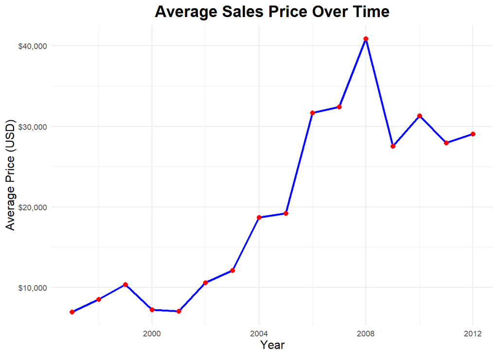

```r
# Aggregate average sales price per year
sales_price_over_time <- art_sales %>%
  group_by(year) %>%  # Get the average price in each year
  summarise(avg_price = mean(price_usd, na.rm = TRUE))

# Create a simple line plot to visualize sales price over time
ggplot(sales_price_over_time, aes(x = year, y = avg_price)) +
  geom_line(color = "blue", size = 1) +  # Blue line for trend
  geom_point(color = "red", size = 2) +   # Red points for data
  labs(  # Change the title and labels
    title = "Average Sales Price Over Time",
    x = "Year",
    y = "Average Price (USD)"
  ) +
  scale_y_continuous(labels = scales::dollar) +  # Format y-axis in dollars
  theme_minimal(base_size = 10) +  # Change base font
  theme(
    plot.title = element_text(face = "bold", size = 16, hjust = 0.5),  # Change title style
    axis.title = element_text(size = 12)  # Change axis labels
  )
```

From this plot, we see that starting from 1997, the overall tread of the sale price is increasing with time. In addition, we can see a peak in sale price at 2008 and dropped later, possibly due to economic recession.

### b. Does the distribution of genre of sales across years appear to change?

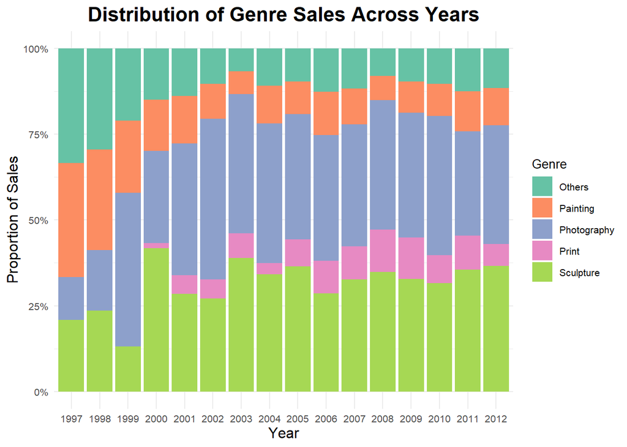

```r
# Reshape genre columns from wide to long format
art_sales_long <- art_sales %>%
  pivot_longer(
    cols = starts_with("Genre___"),  # Select all genre-related columns
    names_to = "genre",
    values_to = "present",
    values_drop_na = TRUE
  ) %>%
  filter(present == 1) %>%  # Keep only rows where the genre is present
  mutate(genre = str_replace(genre, "Genre___", ""))  # Remove "Genre___" prefix from genre labels

# Group data by year and genre to count sales
genre_distribution <- art_sales_long %>%
  group_by(year, genre) %>%
  summarise(count = n(), .groups = "drop")

# Create the updated stacked bar plot
ggplot(genre_distribution, aes(x = factor(year), y = count, fill = genre)) +
  geom_bar(stat = "identity", position = "fill") +
  scale_y_continuous(labels = scales::percent) +
  scale_fill_brewer(palette = "Set2") +  # Set the color palette
  labs(  # Change the title and labels
    title = "Distribution of Genre Sales Across Years",
    x = "Year",
    y = "Proportion of Sales",
    fill = "Genre"
  ) +
  theme_minimal(base_size = 10) +
  theme(  # Change title and axis styles
    plot.title = element_text(size = 16, face = "bold", hjust = 0.5),
    axis.title = element_text(size = 12)
  )
```

From this plot, we see that starting from 1997, the distribution of genres changed over time. For example, (almost) no one bought print before 2000, but more people are having print around 2008. Also, we can see there is a decline in the proportion of people getting paintings and others. The proportion of sculpture and photography is stable over time after 2000.

### c. How does the genre affect the change in sales price over time?

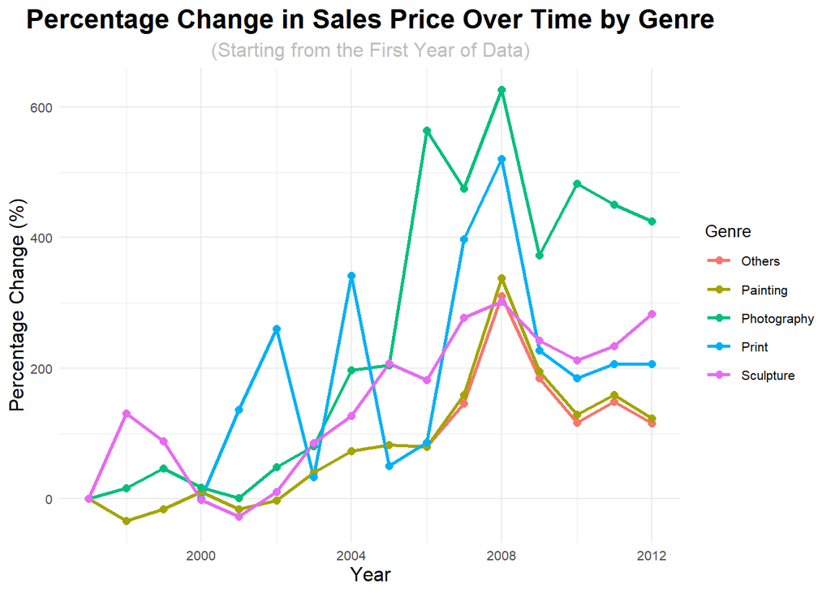

```r
# Calculate average sales price per genre and year
price_by_genre_over_time <- art_sales_long %>%
  group_by(genre, year) %>%
  summarise(avg_price = mean(price_usd, na.rm = TRUE), .groups = "drop")

# For each genre, get the initial price based on the first year of data available
price_by_genre_over_time <- price_by_genre_over_time %>%
  group_by(genre) %>%
  mutate(
    initial_price = first(avg_price),  # Use the first available year as the baseline
    normalized_price = (avg_price / initial_price - 1) * 100  # Calculate percentage change
  ) %>%
  ungroup()

# Create a line plot for all genres on the same plot to show percentage change over time
ggplot(price_by_genre_over_time, aes(x = year, y = normalized_price, color = genre)) +
  geom_line(size = 1) +
  geom_point(size = 2) +
  labs(  # Change the title and labels
    title = "Percentage Change in Sales Price Over Time by Genre",
    subtitle = "(Starting from the First Year of Data)",
    x = "Year",
    y = "Percentage Change (%)",
    color = "Genre"
  ) +
  theme_minimal(base_size = 10) +
  theme(  # Change title and axis styles
    plot.title = element_text(size = 16, face = "bold", hjust = 0.5),
    plot.subtitle = element_text(size = 12, hjust = 0.5, color = "gray"),  # Centered and in gray
    axis.title = element_text(size = 12),
  )
```